# DSDA 1995

Data Science and Society using R

Lecture 15 | Geospatial Data I

## Plan for Today

- Explore plotting geolocated data in R
- Examine plotting data with the `sp` and `sf` packages

## Types of Maps

- We are going to create a few different types of maps, which will require different R packages
  - Static Maps
    - Most common type of visual output
      - `plot()` most commonly used command from base are
      - Can utilize `ggplot()` and `tmap()`
  - Animated Maps
    - Are becoming more widely used than in the past
      - We will make these with `tmap()`
  - Interactive Maps
    - While static and animated maps can enliven geographic datasets, interactive maps can take them to a new level
      - `leaflet()`

## Plotting Simple Features (`sf`)

- As we have already briefly seen, the `sf` package extends the base plot command, so it can be used on `sf` objects
- We are going to create a choropleth map with `sf`

```r
library(sf)

philly_crimes_sf <- st_read("PhillyCrimerate.shp")
glimpse(philly_crimes_sf)
```

```
Rows: 384
Columns: 5
$ GEOID10    <chr> "42101000100", "42101000200", "42101000300", "42101000401",…
$ n_homic    <int> 10, 4, 7, 9, 6, 9, 1, 3, 1, 1, 1, 2, 1, 1, 4, 1, 1, 1, 3, 2…
$ tract_area <dbl> 704688.5, 381197.4, 550949.2, 231327.5, 303868.9, 427352.7,…
$ homic_rate <dbl> 14.190667, 10.493252, 12.705346, 38.905882, 19.745355, 21.0…
$ geometry   <MULTIPOLYGON [m]> MULTIPOLYGON (((1752148 467..., MULTIPOLYGON (…
```

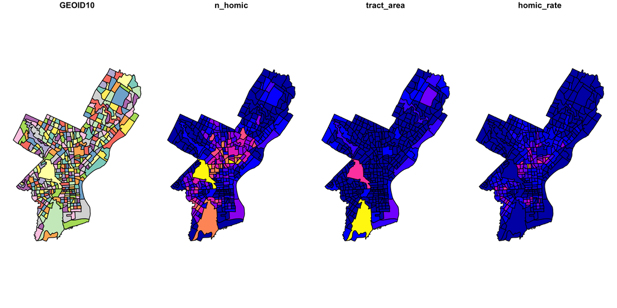

```r
plot(philly_crimes_sf)
```

- Notice that the plot function will try and provide a map of every variable in the data set

## Plotting Simple Features (`sf`)

- To plot a single attribute, we need to provide an object of class `sf`, like so

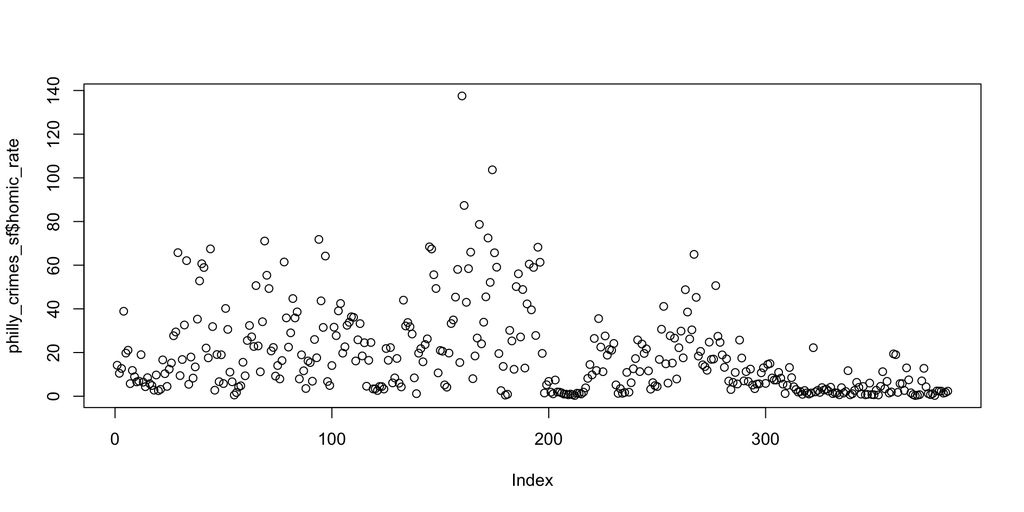

```r
plot(philly_crimes_sf$homic_rate) # this is a numeric vector!
```

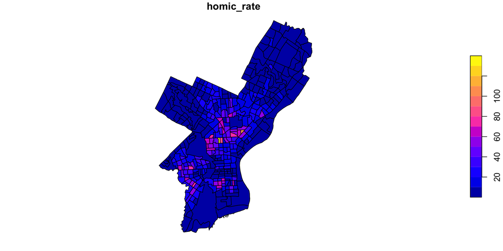

```r
plot(philly_crimes_sf["homic_rate"])
```

- Based on the plot above, it would seem that we have a lot of “empty” geographic units or unevenly distributed

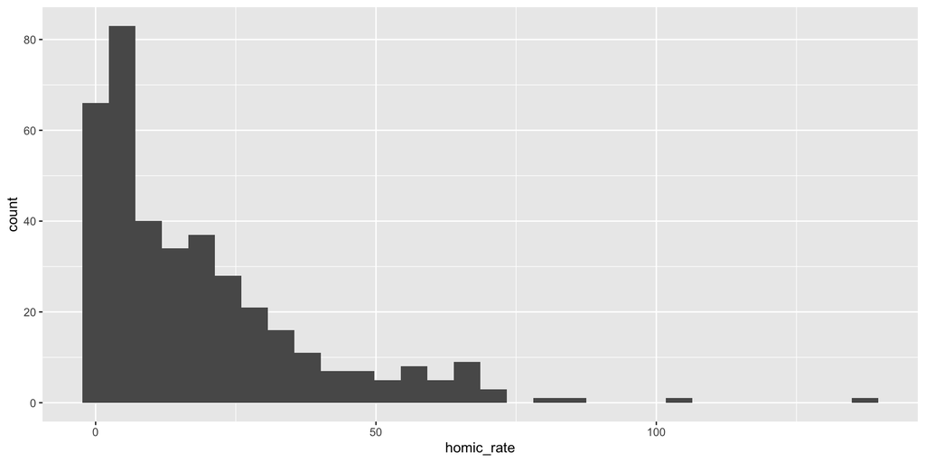

```r
ggplot(philly_crimes_sf) +
  geom_histogram(mapping = aes(x = homic_rate))
```

## Plotting Simple Features (`sf`)

- Let’s break the plot up into quantiles to better distinguish the census tracts with low values

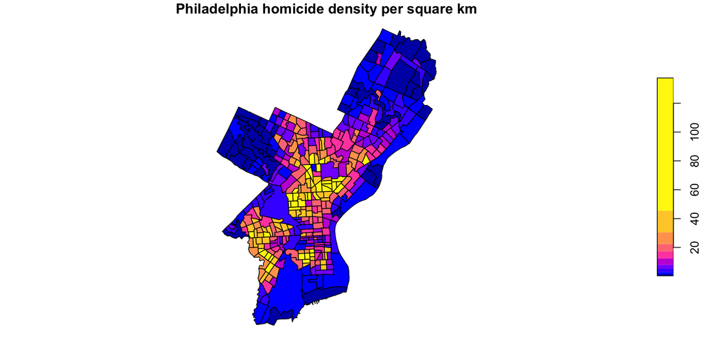

```r
plot(philly_crimes_sf["homic_rate"],
     main = "Philadelphia homicide density per square km",
     breaks = "quantile")
```

## Mapping with `ggplot()`

- `ggplot` is a widely used and powerful plotting library for R as we have utilized over the course of the semester
  - It is not specifically geared towards mapping, but one can generate great maps

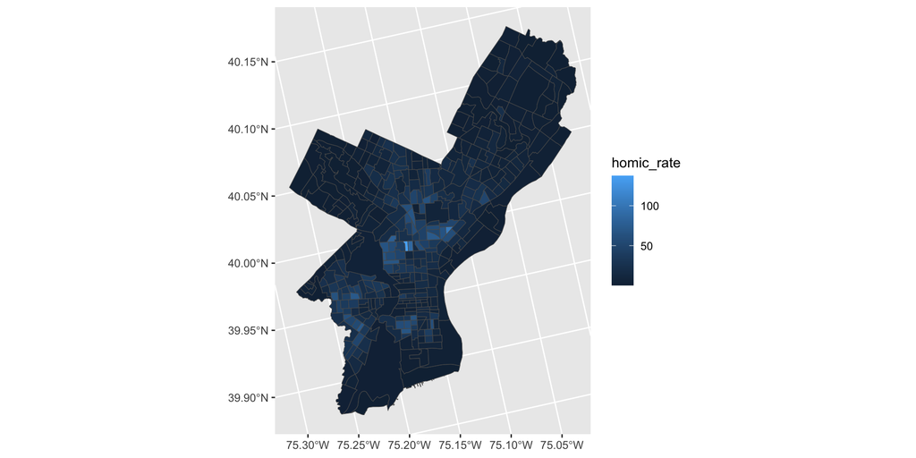

```r
ggplot(philly_crimes_sf) +
  geom_sf(aes(fill=homic_rate))
```

## Mapping with `ggplot()`

- Homicide rate is a continuous variable and is plotted by ggplot as such. If we wanted to plot our map as a ‘true’ choropleth map we need to convert our continuous variable into a categorical one, according to whichever brackets we want to use

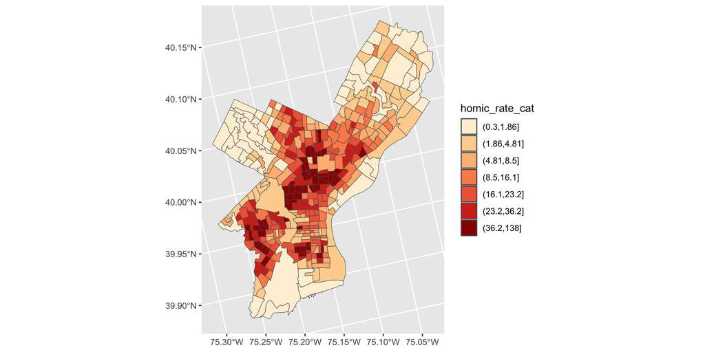

```r
breaks_qt <- classInt::classIntervals(c(min(philly_crimes_sf$homic_rate) - .00001, philly_crimes_sf$homic_rate), n = 7, style = "quantile")

philly_crimes_sf <- mutate(philly_crimes_sf, homic_rate_cat = cut(homic_rate, breaks_qt$brks))

ggplot(philly_crimes_sf) +
    geom_sf(aes(fill=homic_rate_cat)) +
    scale_fill_brewer(palette = "OrRd")
```

## Mapping with `tmap()`

- `tmap` is specifically designed to make creation of thematic maps more convenient
  - Uses `ggplot` syntax
- Useful things to know:
  - `tm_shape()` where we provide the `sf` object (we could also provide an `SpatialPolygonsDataframe`)
  - `tm_polygons()` where we set the attribute variable to map, the break style, and a title

## Mapping with `tmap()`

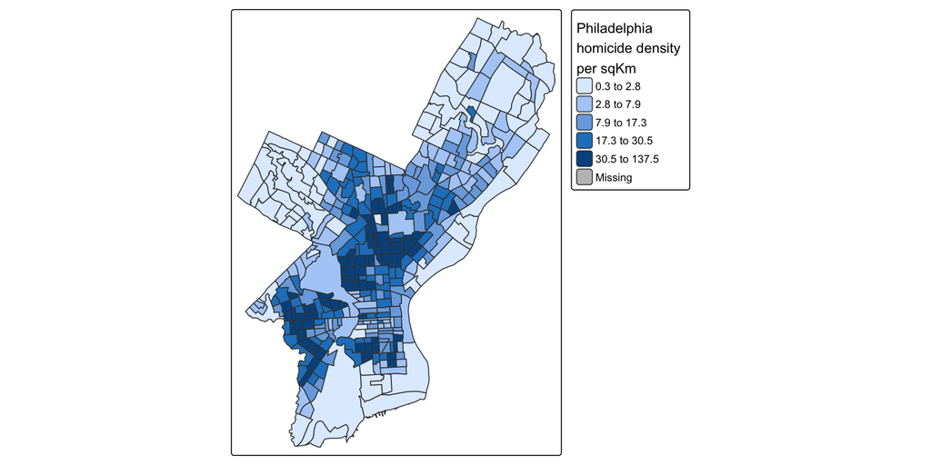

```r
library(tmap)

tm_shape(philly_crimes_sf) +
  tm_polygons("homic_rate",
              style="quantile",
              title="Philadelphia \nhomicide density \nper sqKm")
```

- `tmap` has a very nice feature that allows us to give basic interactivity to the map. We can switch from “plot” mode into “view” mode and call the last plot, like so:

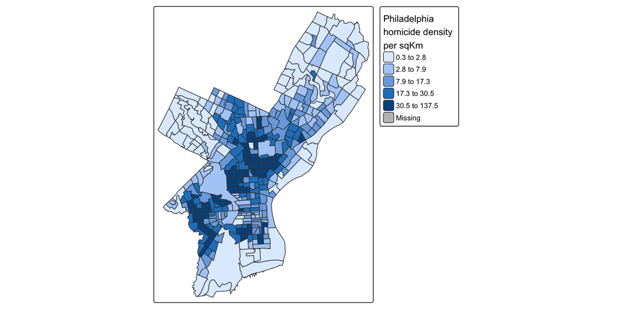

```r
tm_shape(philly_crimes_sf) +
  tm_polygons("homic_rate",
              style="quantile",
              title="Philadelphia \nhomicide density \nper sqKm")
```

```r
tmap_mode("view")
tmap_last()
```

[interactive chart not shown]

## Mapping with `leaflet()`

- `leaflet` provides bindings to the ‘Leaflet’ JavaScript library, “the leading open-source JavaScript library for mobile-friendly interactive maps”
- We have already seen a simple use of leaflet in the `tmap` example
- Let’s build up the map step by step

```r
library(leaflet)

#reproject
philly_WGS84 <- st_transform(philly_crimes_sf, 4326)

leaflet(philly_WGS84) %>%
  addPolygons()
```

[interactive chart not shown]

## Mapping with `leaflet()`

- To map the homicide density we use `addPolygons()`

```r
pal_fun <- colorQuantile("YlOrRd", NULL, n = 5)

p_popup <- paste0("<strong>Homicide Density: </strong>", philly_WGS84$homic_rate)

leaflet(philly_WGS84) %>%
  addPolygons(
    stroke = FALSE, # remove polygon borders
    fillColor = ~pal_fun(homic_rate), # set fill color with function from above and value
    fillOpacity = 0.8, smoothFactor = 0.5, # make it nicer
    popup = p_popup)  # add popup
```

[interactive chart not shown]

## Mapping with `leaflet()`

- We can add a basemap, which defaults to OSM, with `addTiles()`

```r
leaflet(philly_WGS84) %>%
  addPolygons(
    stroke = FALSE,
    fillColor = ~pal_fun(homic_rate),
    fillOpacity = 0.8, smoothFactor = 0.5,
    popup = p_popup) %>%
  addTiles()
```

[interactive chart not shown]

- Lastly, we add a legend with `addLegend()`

```r
leaflet(philly_WGS84) %>%
  addPolygons(
    stroke = FALSE,
    fillColor = ~pal_fun(homic_rate),
    fillOpacity = 0.8, smoothFactor = 0.5,
    popup = p_popup) %>%
  addTiles() %>%
  addLegend("bottomright",  # location
            pal=pal_fun,    # palette function
            values=~homic_rate,  # value to be passed to palette function
            title = 'Philadelphia homicide density per sqkm') # legend title
```

[interactive chart not shown]

## For Next Class

- Review what you learned today
- Do new set of readings:
  - We are going to continue or discuss of relational data
  - USDR Chapter 3.5-3.6
  - GCR Chapter 8.3-8.6
  - MSR Chapter 1-4
  - MSR Chapter 12
    - Follow along the exercises with your own computer
- Bring your laptops to class